# Analysis

Techarla Z Lewis

2023-05-15

```r
pd<- read.csv(file.choose(),header=TRUE)
pd.n <- nrow(pd)
```

## Introduction

| Type Of Variable | Name of Variable | Variable Measurement |
| --- | --- | --- |
| Quantitative | Date | Date[dd-Mmm-Yy] |
| Quantitative | Hours Spent in Zoom | Hours |
| Quantitative | Hours Spent Studying | Hours |
| Quantitative | Hours Spent Sleeping | Hours |
| Quantitative | Number of times leaving the house Unit | [Number] |
| Categorical | Did you watch the news today? | Yes/No |
| Categorical | Accessed social media | Yes/No |
| Categorical | Level of Cleanliness | Scale 1-5 (1—Orderly Spotlessness indicators 2—Ordinary Tidiness 3—Casual Inattention 4—Moderate Dinginess 5—Unkempt Neglect) |
| Quantitative | Number of Kilometers walked | Kilometers |

Throughout this case study, I intend to analyze how I spend my days and if they are as I’ve expected. I’ll also analyze if there is any difference in the way my days are spent in semester one versus semester two. In addition to tracking number of kilometers walked , I will analyze the hours of sleep obtained and total hours spent studying.

```r
pd.analy<-subset(pd, select=c("KiloMeters.Walked", "Hours.Spent.Studying", "Hours.Spent.Sleeping"))
summary(pd.analy)
```

```
##  KiloMeters.Walked Hours.Spent.Studying Hours.Spent.Sleeping
##  Min.   : 0.740    Min.   :0.000        Min.   : 6.000
##  1st Qu.: 2.783    1st Qu.:0.000        1st Qu.: 7.500
##  Median : 4.540    Median :2.500        Median : 8.000
##  Mean   : 4.775    Mean   :2.565        Mean   : 7.937
##  3rd Qu.: 6.320    3rd Qu.:4.000        3rd Qu.: 8.500
##  Max.   :11.970    Max.   :8.000        Max.   :10.000
```

Prior to commencing analysis on these three quantitative variables, I will need to confirm the conditions of independence assumption,randomization condition , 10% condition and nearly normal condition are met.

The independence and randomization condition are considered met for hours spent studying as these values are independent of each other and this is random as this data only covers the past 6 months of school whereas I have completed at least 96 months of school thus far.The 10% condition is considered met as 6 months is less than 10% of 96 months which I have completed whilst perusing my Bachelors degree and other certificates.

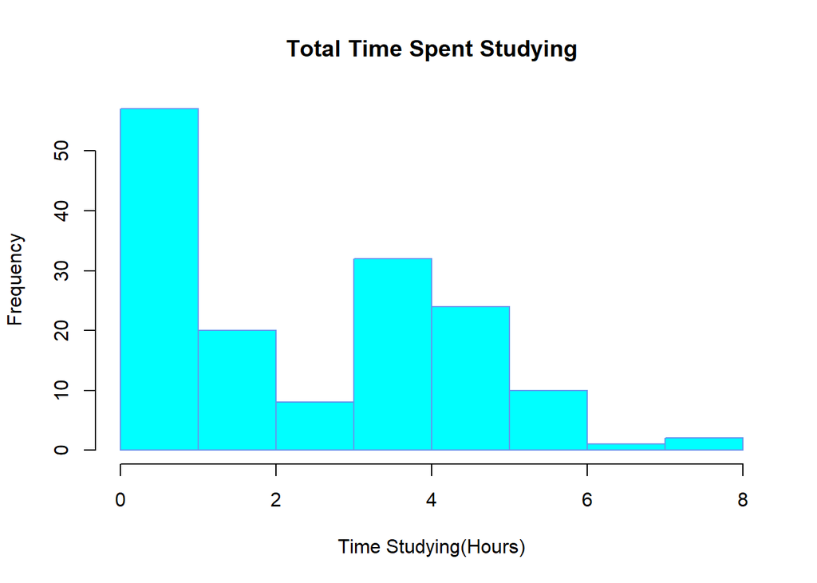

```r
hist(pd$Hours.Spent.Studying,main="Total Time Spent Studying",xlab="Time Studying(Hours)",col="cyan",border="cornflowerblue")
```

Figure 1

Based on Figure 1, we can conclude that the nearly normal condition is met as this graph is right skewed but it isn’t extremely skewed.

The independence and randomization condition are considered met for hours spent studying and total kilometers walked as these values are independent of each other and this is random as this data only covers the past 6 months whereas I would have been walking and sleeping from a young age.The 10% condition is considered met as 6 months is less than 10% of 240 months given I am older than 20 years of age .

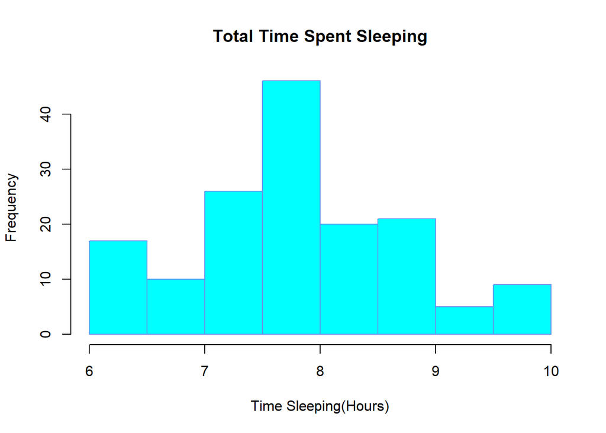

```r
hist(pd$Hours.Spent.Sleeping,main="Total Time Spent Sleeping",xlab="Time Sleeping(Hours)",col="cyan",border="cornflowerblue")
```

Figure 2

Based on Figure 2, we can conclude that the nearly normal condition is met for total hours sleeping as this histogram has a nearly unimodal shape.

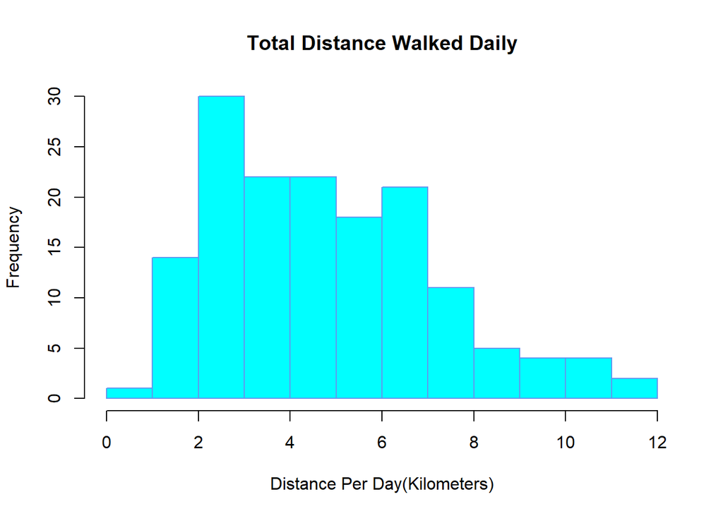

```r
hist(pd$KiloMeters.Walked,main="Total Distance Walked Daily",xlab="Distance Per Day(Kilometers)",col="cyan",border="cornflowerblue")
```

Figure 3

Based on Figure 3, we can conclude that the nearly normal condition is met for total kilometers walked as this histogram has one peak however it is fairly uniformed.

## Body

### Part One: Confidence Intervals

Based on the results provided from the t-test below, I am 95% confident that I spend 2.20 - 2.93 hours studying( 135- 175 mins). These results are not surprising as I don’t study daily however when I do study I strive to study a minimum of four hours.

```r
t.test(pd$Hours.Spent.Studying, conf.level = 0.95)
```

```
##
##  One Sample t-test
##
## data:  pd$Hours.Spent.Studying
## t = 14.027, df = 153, p-value < 2.2e-16
## alternative hypothesis: true mean is not equal to 0
## 95 percent confidence interval:
##  2.203681 2.926189
## sample estimates:
## mean of x
##  2.564935
```

I am quite surprised that I am 95% confident I slept a between 7.78 and 8.09 hours each night over the past six months. I find it hard to get the bed at night as I typically consume coffee to assist me with staying up to complete studying. However, based on these results I can conclude I am getting adequate sleep daily.

```r
t.test(pd$Hours.Spent.Sleeping, conf.level = 0.95)
```

```
##
##  One Sample t-test
##
## data:  pd$Hours.Spent.Sleeping
## t = 101.68, df = 153, p-value < 2.2e-16
## alternative hypothesis: true mean is not equal to 0
## 95 percent confidence interval:
##  7.783055 8.091490
## sample estimates:
## mean of x
##  7.937273
```

At the beginning of 2023, I made the typical goal for myself to exercise more this year , I can confidently say I am 95% certain that I walked between 4.39 to 5.16 kilometers daily. This result is surprising yet reassuring to visually see I am remaining active.

```r
t.test(pd$KiloMeters.Walked, conf.level = 0.95)
```

```
##
##  One Sample t-test
##
## data:  pd$KiloMeters.Walked
## t = 24.353, df = 153, p-value < 2.2e-16
## alternative hypothesis: true mean is not equal to 0
## 95 percent confidence interval:
##  4.387642 5.162358
## sample estimates:
## mean of x
##     4.775
```

### Part Two: One‐Sample Hypothesis Tests

The first hypothesis test will answer the question if I spend more than 3.13 hours studying daily as per McGill university students. This test has a p value of 0.9988 and a critical value of 1.654874. Given the p value is more than the hypothesis,level of significance 0.05,which means I will fail to reject the null. The term ‘fail to reject the null’ means there isn’t sufficient evidence to support the claim that I spend at least 3.13 hours studying daily.

$H_0: \mu = 3.13$

$H_A: \mu \gt 3.13$

```r
t.test(pd$Hours.Spent.Studying,mu = 3.13, alternative="greater")
```

```
##
##  One Sample t-test
##
## data:  pd$Hours.Spent.Studying
## t = -3.0902, df = 153, p-value = 0.9988
## alternative hypothesis: true mean is greater than 3.13
## 95 percent confidence interval:
##  2.262327      Inf
## sample estimates:
## mean of x
##  2.564935
```

```r
qt(0.05,df=153,lower.tail = FALSE)
```

```
## [1] 1.654874
```

The second hypothesis test will analyze if I spend an average eight hours sleeping daily. This hypothesis test was chosen because when I started learning more about health , most online resources recommended a minimum of eight hours rest nightly. Upon conducting the hypothesis test on hours slept over last 6 months, I obtained a p-value of 0.4229 and a critical value of 1.97559. Given the p value was significantly greater then the level of significance I will fail to reject the null. This means there isn’t sufficient data to support the claim that I do not spend 8 hours sleeping.

$H_0: \mu = 8$

$H_A: \mu \neq 8$

```r
t.test(pd$Hours.Spent.Sleeping,mu=8, alternative="two.sided")
```

```
##
##  One Sample t-test
##
## data:  pd$Hours.Spent.Sleeping
## t = -0.80356, df = 153, p-value = 0.4229
## alternative hypothesis: true mean is not equal to 8
## 95 percent confidence interval:
##  7.783055 8.091490
## sample estimates:
## mean of x
##  7.937273
```

```r
qt(0.05/2,df=153)
```

```
## [1] -1.97559
```

```r
qt(0.05/2,df=153,lower.tail = FALSE)
```

```
## [1] 1.97559
```

The third hypothesis I will analyze is if I walk at least 5 kilometers daily. As I commenced the year, I decided I wanted to be more active when working from home, I initially set a daily goal of 3 kilometers however as It became more natural , my goal increased to 5 daily. In this test, I’ll analysis the hypotheses that I walk 5 kilometers daily and an alternative hypothesis that I walk more than 5 kilometers daily. Based on the data captured over the last 5 months, the p-value is 0.8735 and a critical value of 1.654874. Given the p-value , I will fail to reject the null hypothesis , which means there isn’t enough evidence to conclude that I walk more than 5 kilometers daily.

$H_0: \mu = 5$

$H_A: \mu \gt 5$

```r
t.test(pd$KiloMeters.Walked,mu = 5.0, alternative="greater")
```

```
##
##  One Sample t-test
##
## data:  pd$KiloMeters.Walked
## t = -1.1475, df = 153, p-value = 0.8735
## alternative hypothesis: true mean is greater than 5
## 95 percent confidence interval:
##  4.450525      Inf
## sample estimates:
## mean of x
##     4.775
```

```r
qt(0.05,df=153,lower.tail = FALSE)
```

```
## [1] 1.654874
```

### Part Three : Two‐Sample Hypothesis Tests

```r
W23 <- subset(pd, SemeterAttended == 'W23')
S23 <- subset(pd, SemeterAttended == 'S23')
```

Both are these groups can be considered independent as they do not have any affect on each other. Although there are two consecutive semesters, the materials learnt would have been, different as well as the time required to grasp the materials taught in the courses. Another factor to consider would be the amount of courses taken as in semester 1(Winter 2023) I took 4 courses , whereas in semester two (Summer 2023), I’m taking five courses.

```r
#install.packages('dplyr', repos = "http://cran.us.r-project.org")
library("dplyr")
set.seed(1)
W23r <- sample_n(W23,10)
S23r <- sample_n(S23,10)
```

The purpose of this test is to analyze if I spent more time studying in semester one (w23) than I did in semester two(s23). Given a critical value of 1.73 and a p value of 0.2359. Using the probability value, we can fail to reject the null hypothesis. This means that there isn’t sufficient evidence that there isn’t a significant difference between the mean study for each semester

$H_0: \mu 1 - \mu S23 = 0$

$H_A: \mu 1 - \mu S23 \gt 0$

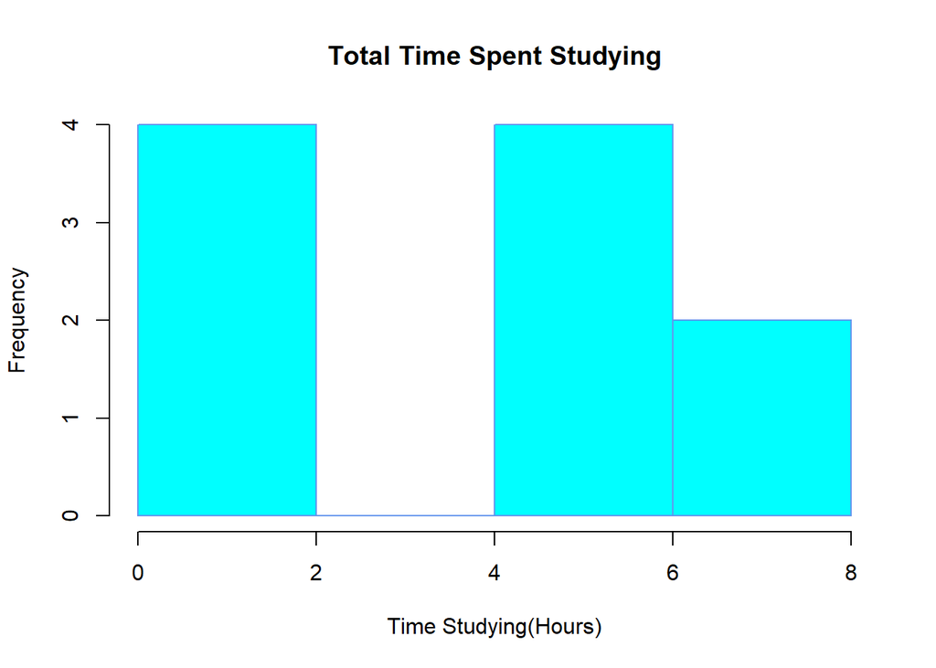

```r
hist(W23r$Hours.Spent.Studying,main="Total Time Spent Studying",xlab="Time Studying(Hours)",col="cyan",border="cornflowerblue")
```

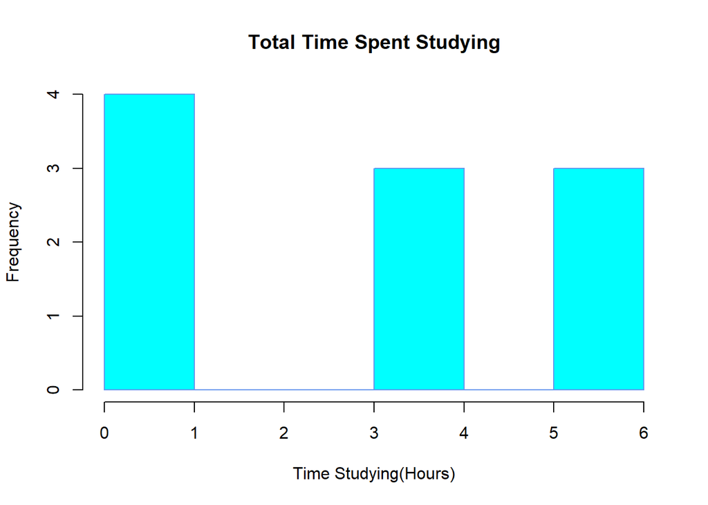

```r
hist(S23r$Hours.Spent.Studying,main="Total Time Spent Studying",xlab="Time Studying(Hours)",col="cyan",border="cornflowerblue")
```

```r
t.test(W23r$Hours.Spent.Studying,S23r$Hours.Spent.Studying, alternative="greater")
```

```
##
##  Welch Two Sample t-test
##
## data:  W23r$Hours.Spent.Studying and S23r$Hours.Spent.Studying
## t = 0.73512, df = 17.992, p-value = 0.2359
## alternative hypothesis: true difference in means is greater than 0
## 95 percent confidence interval:
##  -1.223052       Inf
## sample estimates:
## mean of x mean of y
##       3.9       3.0
```

```r
qt(0.05, 17.992, lower.tail=FALSE)
```

```
## [1] 1.734105
```

The fifth hypothesis test which will be conducted is a paired t-test. This was selected as we are matching observations. Given , the data is from the same individual,myself,analyzing studying habits in the first semester and the second semester.

$H_0: \mu d w23-s23 = 0$

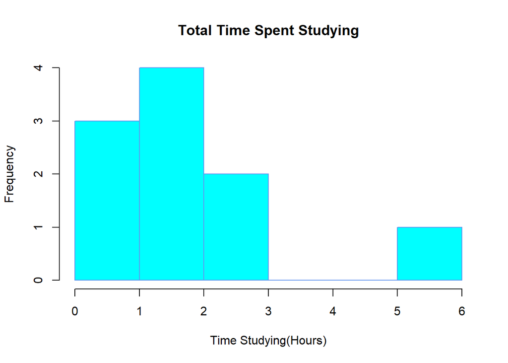

```r
w10 <- W23[1:10,]
s10 <- S23[1:10,]
hist(w10$Hours.Spent.Studying,main="Total Time Spent Studying",xlab="Time Studying(Hours)",col="cyan",border="cornflowerblue")
```

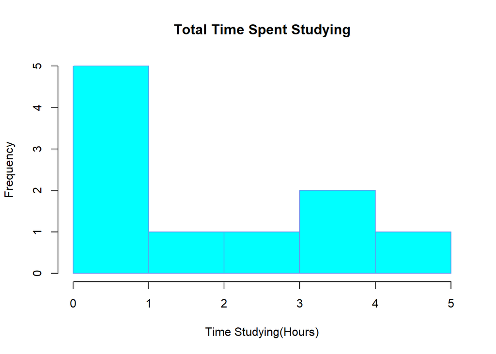

```r
hist(s10$Hours.Spent.Studying,main="Total Time Spent Studying",xlab="Time Studying(Hours)",col="cyan",border="cornflowerblue")
```

```r
t.test(w10$Hours.Spent.Studying,s10$Hours.Spent.Studying,   alternative="two.sided", var.equal = FALSE , paired= TRUE)
```

```
##
##  Paired t-test
##
## data:  w10$Hours.Spent.Studying and s10$Hours.Spent.Studying
## t = 0.26941, df = 9, p-value = 0.7937
## alternative hypothesis: true mean difference is not equal to 0
## 95 percent confidence interval:
##  -1.479354  1.879354
## sample estimates:
## mean difference
##             0.2
```

```r
qt(0.05/2, df=10+10-2)
```

```
## [1] -2.100922
```

```r
qt(0.05/2, df=10+10-2,lower.tail = FALSE)
```

```
## [1] 2.100922
```

## Conclusion

Further insight was taken to compare the habits in semester one and semester two . A paired and two sample test was taken on the first 10 days and 10 random days respectively and they showed there wasn’t much difference in the means for the two semesters.